# **Analyzing Olympic Data From 1896-2016 and Exploring Relationships Within the Data**

*By: Sneha Arya, Maeric Barrows, Derek Denoon, Varun Kaveti, Kate Miller, and Ayla Orona*

## **Introduction**

The Olympics is the most iconic sports event in the world that has been relevant for hundreds of years. Because of this, the vast amount of Olympic data can cause problems for further analysis. This huge amount of data can make it difficult to filter and draw relationships between variables. Another problem relating to large amounts of data is we sometimes are not able to make sense of it. Because of this, specific research questions need to be made in order to gather useful and relevant data.

Our group conducted data analysis on 120 years of Olympic Data. Throughout this, we encountered some minor problems related to our specified analysis questions. Because the data set is so large, it affected some results causing us to make the questions more specific. For example, there are duplicate athlete names because they competed in multiple different events for each Olympic season. This was a problem for questions pertaining to specific athletes or countries because of irrelevant continuous data. However, this was also a benefit for questions regarding athlete appearances or data throughout the years.

The Olympics is an iconic world sports event that has been ongoing for hundreds of years. This means there is lots of data to be discovered and analyzed. The conducted analysis of 120 years of Olympic data can provide us with information about individual athlete performance and country performance. With this analysis, in the future, predictions can be made about further performances to predict athlete outcomes along with country outcomes. The rise of data analysis and statistics in sports is advancing and becoming more popular to determine results. Our data analysis is a little sector of this by researching and providing visualizations for different topics that provide useful and interesting information on the results and variables of the Olympics.

206 nations all with a varying number of athletes compete in the Olympics. Lots of athletes compete in various events relating to their sport like gymnastics, track and field, swimming, etc. Depending on the sport, all athletes are of different height, weight, and sex. There are three medals, bronze which is third place, silver which is second place, and gold which is first place. To learn more about the Olympic games click on this link: https://www.britannica.com/sports/Olympic-Games. To become familiar with the data set we used, click on this link: https://www.kaggle.com/datasets/heesoo37/120-years-of-olympic-history-athletes-and-results

## **Exploratory Data Analysis**

The following code shows how we imported the data csv and necessary python packages to create our visualizations to analyze the data. It shows the total number of rows and columns present in the dataset, as well as the column names. Lastly, we included the summary statistics for all numerical variables to show the average number of medals won and other important information such as height or weight that may play a part in performance in some sports.

```python
import pandas as pd
import numpy as np
import matplotlib.pyplot as plt
df = pd.read_csv('/content/athlete_events.csv')
```

```python
df.head(5)
```

|  | ID | Name | Sex | Age | Height | Weight | Team | NOC | Games | Year | Season | City | Sport | Event | Medal |
| --- | --- | --- | --- | --- | --- | --- | --- | --- | --- | --- | --- | --- | --- | --- | --- |
| 0 | 1 | A Dijiang | M | 24.0 | 180.0 | 80.0 | China | CHN | 1992 Summer | 1992 | Summer | Barcelona | Basketball | Basketball Men's Basketball | NaN |
| 1 | 2 | A Lamusi | M | 23.0 | 170.0 | 60.0 | China | CHN | 2012 Summer | 2012 | Summer | London | Judo | Judo Men's Extra-Lightweight | NaN |
| 2 | 3 | Gunnar Nielsen Aaby | M | 24.0 | NaN | NaN | Denmark | DEN | 1920 Summer | 1920 | Summer | Antwerpen | Football | Football Men's Football | NaN |
| 3 | 4 | Edgar Lindenau Aabye | M | 34.0 | NaN | NaN | Denmark/Sweden | DEN | 1900 Summer | 1900 | Summer | Paris | Tug-Of-War | Tug-Of-War Men's Tug-Of-War | Gold |
| 4 | 5 | Christine Jacoba Aaftink | F | 21.0 | 185.0 | 82.0 | Netherlands | NED | 1988 Winter | 1988 | Winter | Calgary | Speed Skating | Speed Skating Women's 500 metres | NaN |

```python
# Shows total columns and total rows
print("Shape of the DataFrame:")
print(df.shape)
```

```
Shape of the DataFrame:
(271116, 15)
```

```python
# Display the column names
print("Column names:")
print(df.columns.tolist())
```

```
Column names:
['ID', 'Name', 'Sex', 'Age', 'Height', 'Weight', 'Team', 'NOC', 'Games', 'Year', 'Season', 'City', 'Sport', 'Event', 'Medal']
```

```python
print("Print Keys:")
df.keys()
```

```
Print Keys:
```

```
Index(['ID', 'Name', 'Sex', 'Age', 'Height', 'Weight', 'Team', 'NOC', 'Games',
       'Year', 'Season', 'City', 'Sport', 'Event', 'Medal'],
      dtype='object')
```

```python
# Display summary statistics for numerical columns
print("Summary statistics for numerical columns:")
df.describe()
```

```
Summary statistics for numerical columns:
```

|  | ID | Age | Height | Weight | Year |
| --- | --- | --- | --- | --- | --- |
| count | 271116.000000 | 261642.000000 | 210945.000000 | 208241.000000 | 271116.000000 |
| mean | 68248.954396 | 25.556898 | 175.338970 | 70.702393 | 1978.378480 |
| std | 39022.286345 | 6.393561 | 10.518462 | 14.348020 | 29.877632 |
| min | 1.000000 | 10.000000 | 127.000000 | 25.000000 | 1896.000000 |
| 25% | 34643.000000 | 21.000000 | 168.000000 | 60.000000 | 1960.000000 |
| 50% | 68205.000000 | 24.000000 | 175.000000 | 70.000000 | 1988.000000 |
| 75% | 102097.250000 | 28.000000 | 183.000000 | 79.000000 | 2002.000000 |
| max | 135571.000000 | 97.000000 | 226.000000 | 214.000000 | 2016.000000 |

```python
# Display overall information about the DataFrame
print("Overall information about the DataFrame:")
df.info()
```

```
Overall information about the DataFrame:
<class 'pandas.core.frame.DataFrame'>
RangeIndex: 271116 entries, 0 to 271115
Data columns (total 15 columns):
 #   Column  Non-Null Count   Dtype
---  ------  --------------   -----
 0   ID      271116 non-null  int64
 1   Name    271116 non-null  object
 2   Sex     271116 non-null  object
 3   Age     261642 non-null  float64
 4   Height  210945 non-null  float64
 5   Weight  208241 non-null  float64
 6   Team    271116 non-null  object
 7   NOC     271116 non-null  object
 8   Games   271116 non-null  object
 9   Year    271116 non-null  int64
 10  Season  271116 non-null  object
 11  City    271116 non-null  object
 12  Sport   271116 non-null  object
 13  Event   271116 non-null  object
 14  Medal   39783 non-null   object
dtypes: float64(3), int64(2), object(10)
memory usage: 31.0+ MB
```

## **Questions to Address Through Data Analysis**

### **Question 1**: What 20 countries have earned the most Summer Olympic medals? How about the Winter Olympics?

#### Summer

```python
## SUMMER
# Sort data
summer = df[["NOC", "Season", "Medal"]]
summer = summer.loc[summer["Season"] == "Summer"]
summer = summer.dropna(axis='index', subset=["NOC", "Season", "Medal"])
summer
```

|  | NOC | Season | Medal |
| --- | --- | --- | --- |
| 3 | DEN | Summer | Gold |
| 37 | FIN | Summer | Bronze |
| 38 | FIN | Summer | Bronze |
| 41 | FIN | Summer | Bronze |
| 42 | FIN | Summer | Gold |
| ... | ... | ... | ... |
| 271078 | URS | Summer | Silver |
| 271080 | URS | Summer | Bronze |
| 271082 | POL | Summer | Bronze |
| 271102 | RUS | Summer | Bronze |
| 271103 | RUS | Summer | Silver |

34088 rows × 3 columns

```python
most_summer = summer.groupby("NOC").size()
most_summer = most_summer.sort_values(ascending=False)
most_summer = most_summer.head(20)
most_summer
```

```
NOC
USA    5002
URS    2063
GBR    1985
GER    1779
FRA    1627
ITA    1446
AUS    1304
HUN    1123
SWE    1108
NED     918
CHN     909
RUS     905
JPN     850
GDR     843
CAN     741
ROU     651
DEN     592
NOR     590
KOR     552
POL     538
dtype: int64
```

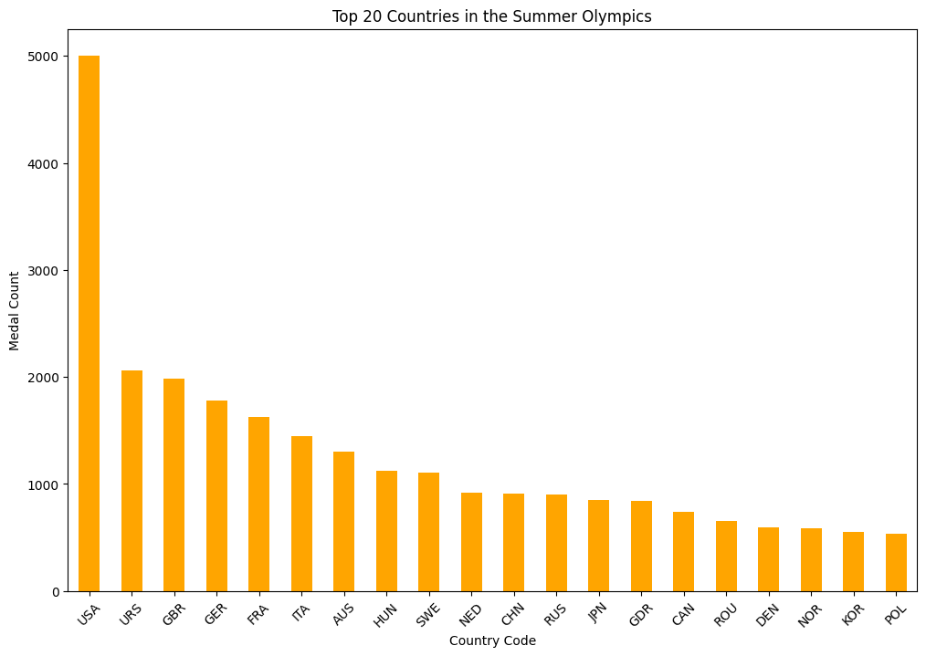

```python
# Make the plot
plt.figure(figsize=(12, 8))
most_summer.plot(kind="bar", color = "orange")
plt.title("Top 20 Countries in the Summer Olympics")
plt.xlabel("Country Code")
plt.ylabel("Medal Count")
plt.xticks(rotation=45)
plt.show()
```

This plot shows that the United States has historically earned the most medals in the Summer Olympics, The USSR, Great Britain, Germany, and France are the next countries behind. This graph shows the 20 highest medal getters. Note that the USSR and Russia are counted as separate countries due to their different codes. If you were to combine the medal counts for the USSR and Russia, they would still have the second most Summer medals.

#### Winter

```python
## WINTER
# Sort data
winter = df[["NOC", "Season", "Medal"]]
winter = winter.loc[winter["Season"] == "Winter"]
winter = winter.dropna(axis='index', subset=["NOC", "Season", "Medal"])
winter
```

|  | NOC | Season | Medal |
| --- | --- | --- | --- |
| 40 | FIN | Winter | Bronze |
| 60 | NOR | Winter | Gold |
| 61 | NOR | Winter | Bronze |
| 63 | NOR | Winter | Silver |
| 64 | NOR | Winter | Bronze |
| ... | ... | ... | ... |
| 270641 | EUN | Winter | Gold |
| 270827 | YUG | Winter | Silver |
| 270876 | SUI | Winter | Gold |
| 270878 | SUI | Winter | Bronze |
| 270886 | SUI | Winter | Bronze |

5695 rows × 3 columns

```python
most_winter = winter.groupby("NOC").size()
most_winter = most_winter.sort_values(ascending=False)
most_winter = most_winter.head(20)
most_winter
```

```
NOC
USA    635
CAN    611
NOR    443
URS    440
SWE    428
FIN    426
GER    386
AUT    280
SUI    275
RUS    260
ITA    191
GDR    162
TCH    158
FRA    150
NED    122
KOR     86
GBR     83
FRG     82
CHN     80
CZE     73
dtype: int64
```

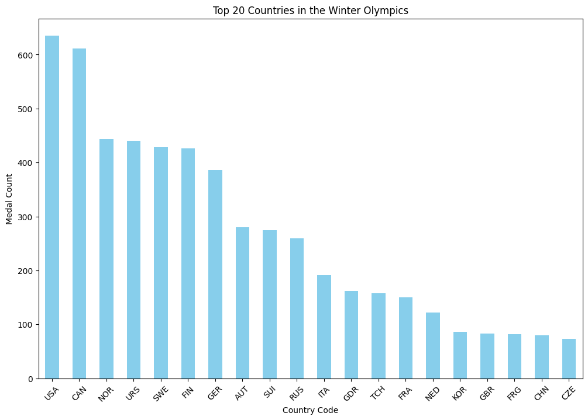

```python
# Make the plot
plt.figure(figsize=(12, 8))
most_winter.plot(kind="bar", color = "skyblue")
plt.title("Top 20 Countries in the Winter Olympics")
plt.xlabel("Country Code")
plt.ylabel("Medal Count")
plt.xticks(rotation=45)
plt.show()
```

As for the Winter Olympics, the United States has also won the most medals. Canada is very close in second place, with Norway, the USSR, Sweden, and Finland close behind. In the case that the USSR and Russia were counted as the same country, they would actually have the most Winter medals.

### **Question 2:** Have different countries been more successful in different time periods?

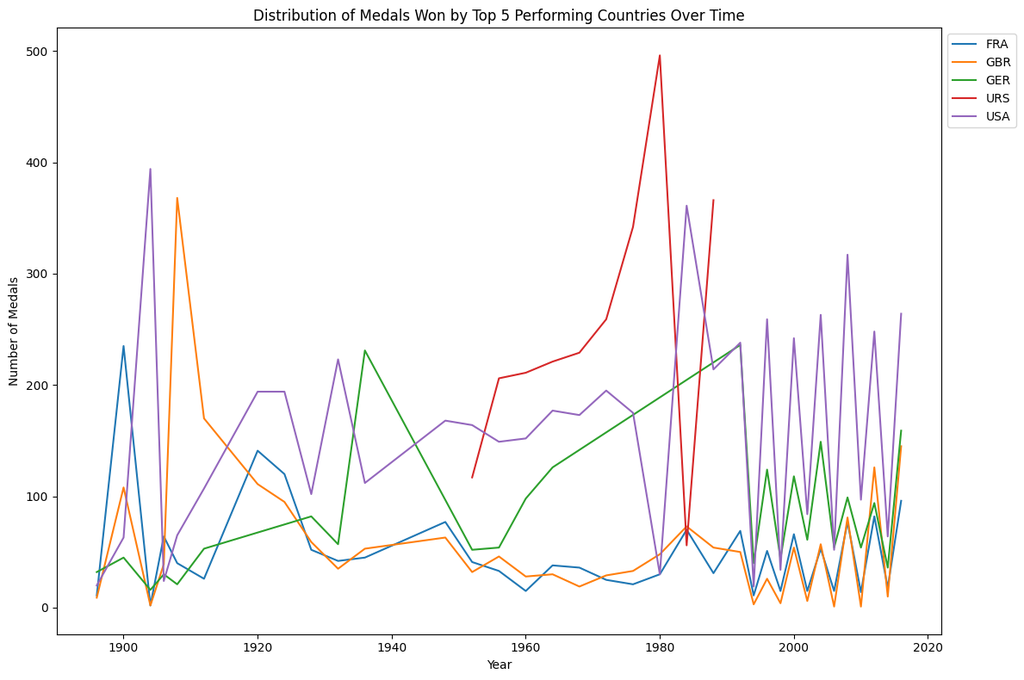

```python
# Finds the total number of medals per country (gold, silver, and bronze)
total_medals_per_country = df.groupby('NOC')['Medal'].count().sort_values(ascending=False)
# Selects the top 5 performing countries
top_5_countries = total_medals_per_country.head(5).index
# Finds the data for the top 5 performing countries
top_5_country_data = df[df['NOC'].isin(top_5_countries)]
# Finds the medal count for the top 5 performing countries
top_5_country_year_medals = top_5_country_data.groupby(['NOC', 'Year'])['Medal'].count().reset_index()
plt.figure(figsize=(12, 8))
# Iterates over unique countries in the ‘NOC’ column
for country in top_5_country_year_medals['NOC'].unique():
# Filters data for the current country
  country_data = top_5_country_year_medals[top_5_country_year_medals['NOC'] == country]
# Creates the plot
  plt.plot(country_data['Year'], country_data['Medal'], label=country)
plt.title('Distribution of Medals Won by Top 5 Performing Countries Over Time')
plt.xlabel('Year')
plt.ylabel('Number of Medals')
plt.legend(loc='upper left', bbox_to_anchor =(1, 1))
plt.tight_layout()
plt.show()
```

The visualization showcases the top 5 countries in terms of medals won throughout the years of the data set (1896 - 2016). URS, the country code for the former Soviet Union, had a large peak in performance around 1980, declined in the next Olympics following the 1980 Olympics, and then spiked back up for the one following that. One can see that all four other countries involved in the visualization have competed in the Olympics every time they have occurred since 1896. URS competed from about 1950 - 1990 and then changed their country code to RUS. From 1990 - 2020, the USA has consistently had the most medals, though France, Great Britain, and the United States all had peaks of high medaling in the early years of the Olympics.

### **Question 3:** Who has the most medals won for women in the summer Olympics?

```python
# Includes only female athletes in the Summer Olympics who have won medals
df_women_summer = df[(df['Sex'] == 'F') & (df['Season'] == 'Summer') & (df['Medal'].notna())]
medal_counts = df_women_summer.groupby(['Name', 'Sport'])['Medal'].count().reset_index(name='Medal Count')
# Sort the medal counts in descending order to find the top medal winners and select the top 11
top_medal_winners = medal_counts.sort_values(by='Medal Count', ascending=False).head(11)
print(top_medal_winners)
```

```
                                                 Name          Sport  \
3133               Larysa Semenivna Latynina (Diriy-)     Gymnastics
641                            Birgit Fischer-Schmidt       Canoeing
1179             Dara Grace Torres (-Hoffman, -Minas)       Swimming
4341                    Natalie Anne Coughlin (-Hall)       Swimming
2485  Jennifer Elisabeth "Jenny" Thompson (-Cumpelik)       Swimming
5929                           Vra slavsk (-Odloilov)     Gymnastics
1701                            Franziska van Almsick       Swimming
6396                        gnes Keleti-Srkny (Klein)     Gymnastics
2336                            Isabelle Regina Werth  Equestrianism
4808                      Polina Hryhorivna Astakhova     Gymnastics
4093                         Merlene Joyce Ottey-Page      Athletics

      Medal Count
3133           18
641            12
1179           12
4341           12
2485           12
5929           11
1701           10
6396           10
2336           10
4808           10
4093            9
```

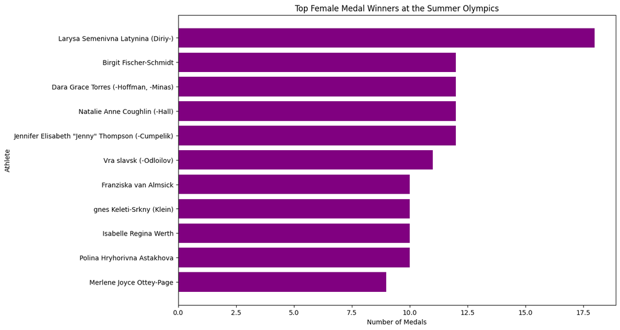

```python
# Data Visualization code
plt.figure(figsize=(12, 8))
plt.barh(top_medal_winners['Name'], top_medal_winners['Medal Count'], color='purple')
plt.xlabel('Number of Medals')
plt.ylabel('Athlete')
plt.title('Top Female Medal Winners at the Summer Olympics')
plt.gca().invert_yaxis()
plt.show()
```

The visualization shows the 11 highest performing female athletes for the summer Olympics, where many of the women have more than 7 medals apiece.

### **Question 4:** How many appearances did some athletes make?

```python
# Group by name and make the count column ‘Appearances’
athlete_count = df.groupby('Name').size().reset_index(name='Appearances')
# Make it descending
athlete_count = athlete_count.sort_values(by='Appearances', ascending=False)
athlete_count.head(10)
```

|  | Name | Appearances |
| --- | --- | --- |
| 107135 | Robert Tait McKenzie | 58 |
| 47116 | Heikki Ilmari Savolainen | 39 |
| 63766 | Joseph "Josy" Stoffel | 38 |
| 52174 | Ioannis Theofilakis | 36 |
| 118712 | Takashi Ono | 33 |
| 56949 | Jean Lucien Nicolas Jacoby | 32 |
| 4622 | Alexandros Theofilakis | 32 |
| 4873 | Alfrd (Arnold-) Hajs (Guttmann-) | 32 |
| 7748 | Andreas Wecker | 32 |
| 4920 | Alfred August "Al" Jochim | 31 |

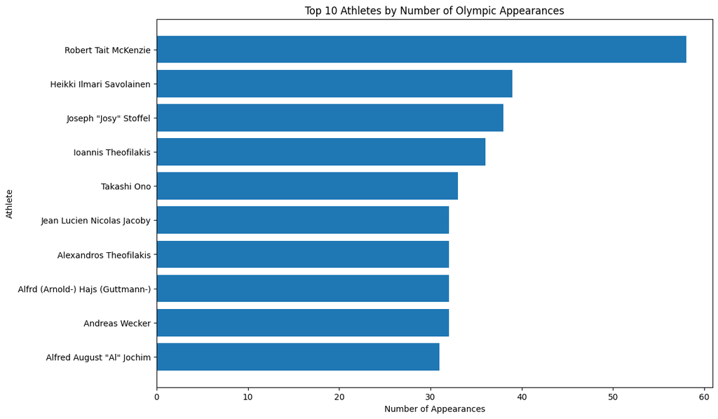

```python
# Plot the data with the top 10 appearances
plt.figure(figsize=(12, 8))
plt.barh(athlete_count['Name'].head(10), athlete_count['Appearances'].head(10))
plt.xlabel('Number of Appearances')
plt.ylabel('Athlete')
plt.title('Top 10 Athletes by Number of Olympic Appearances')
plt.gca().invert_yaxis()
plt.show()
```

This bar chart measures the top 10 Olympic athlete appearances. Based on the graph, we can see Robert Tait McKenzie has the most appearances resulting in almost 60. Robert Tait McKenzie was an Olympic Sculptor. From 1912 to 1948, the Olympics included fine art competitions as an official event. This graph takes into account the amount of events an athlete competed in and the years they have appeared in.

### **Question 5:** How many countries competed in each Olympics?

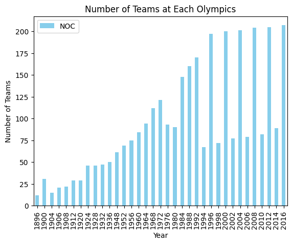

```python
# Filter to just year and NOC
year_noc = df[['Year','NOC']]
# Group by year
grouped_year = year_noc.groupby('Year')
# Number of unique Olympic codes (teams) grouped by year
plot = grouped_year.nunique()

plt.figure(figsize=(12, 8))
# Plotting code
plot.plot(kind='bar',color = "skyblue")
plt.title("Number of Teams at Each Olympics")
plt.xlabel("Year")
plt.ylabel("Number of Teams")
```

The bar chart shows the number of teams that compete by the year in each olympics. The data shows a left skew which implies that the olympics grew in popularity slowly over time, and the number of nations competing finally reached 100 in 1968. In the 1990s and after, there appears to be an oscillation between 200+ teams competing and below 100. This visualization shows the drop off between the teams that choose to participate in the summer olympics vs. winter olympics.

### **Question 6:** What are the oldest athletes to win a gold medal? What sports did they play?

```python
# Finds the athletes who have won a gold medal
gold_medalists = df[df['Medal'] == 'Gold']
# Finds the 100 oldest gold medal winners and sorts them from oldest to youngest
oldest_gold_medalists = gold_medalists.sort_values(by = 'Age', ascending = False).head(100)
# Obtains the sports of the oldest athletes and their age
oldest_athletes_sports = oldest_gold_medalists[['Age', 'Sport']]
print(oldest_athletes_sports)
```

```
         Age          Sport
233390  64.0       Shooting
105199  64.0          Roque
226374  63.0        Archery
190952  63.0        Archery
261102  63.0        Archery
...      ...            ...
21800   48.0        Sailing
200925  48.0        Sailing
115627  48.0       Shooting
115628  48.0       Shooting
121149  48.0  Equestrianism

[100 rows x 2 columns]
```

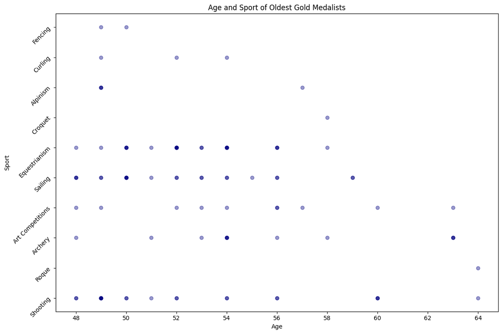

```python
# Creates a scatter plot
plt.figure(figsize=(12, 8))
plt.scatter(oldest_athletes_sports['Age'], oldest_athletes_sports['Sport'], color = 'navy', alpha = 0.4)
plt.title('Age and Sport of Oldest Gold Medalists')
plt.xlabel('Age')
plt.ylabel('Sport')
plt.yticks(rotation = 45, ha = 'right')
plt.tight_layout()
plt.show()
```

The darker circles on the visualization represent that there may be multiple individuals who were a specific age in a specific sport who won a gold medal. The oldest individuals to win gold medals were 64 years old and were in Roque and Shooting. There were also a couple individuals who were 63 when they won their gold medals, in Art Competitions and Archery. The data shows that there is not an age limit to winning an Olympic medal, especially since several individuals were winning medals well into their forties and fifties in sports that may require physical endurance.

```python
# Remove rows where the 'Medal' column contains missing values
df = df.dropna(subset=['Medal'])
# Only include records from the years before 1994
df = df[df['Year'] < 1994]
# Group the data by 'Year', 'Sex', and 'Medal'
# Each medal type is a column
# Fill any missing values with 0 (because no medals of that type were awarded in that group)
medal_counts = df.groupby(['Year', 'Sex', 'Medal']).size().unstack(fill_value=0)
print(medal_counts.head(100))
```

```
Medal     Bronze  Gold  Silver
Year Sex
1896 M        38    62      43
1900 F         5     4       4
     M       170   197     224
1904 F         2     6       2
     M       148   167     161
1906 F         2     2       2
     M       143   155     154
1908 F         5     6       5
     M       251   288     276
1912 F        10    10      10
     M       290   316     305
1920 F        14    15      15
     M       353   478     433
1924 F        17    17      18
     M       294   315     301
1928 F        35    34      34
     M       246   241     233
1932 F        22    22      24
     M       210   239     222
1936 F        33    32      32
     M       297   316     315
1948 F        40    38      38
     M       285   292     294
1952 F        52    53      53
     M       295   298     282
1956 F        58    54      59
     M       290   299     283
1960 F        60    69      66
     M       297   290     276
1964 F        73    86      87
     M       328   322     319
1968 F        84    90      87
     M       337   335     323
1972 F        94   102      99
     M       391   372     356
1976 F       145   148     147
     M       373   360     358
1980 F       161   162     162
     M       381   367     369
1984 F       182   188     178
     M       394   383     373
1988 F       212   199     206
     M       425   408     395
1992 F       237   230     224
     M       473   433     433
```

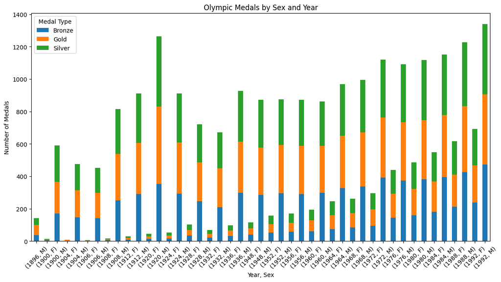

```python
# Visualization code
fig, ax = plt.subplots(figsize=(14, 7))
# This ensures correct formatting since there is a lot of data
medal_counts.plot(kind='bar', stacked=True, ax=ax)
plt.title('Olympic Medals by Sex and Year')
plt.xlabel('Year, Sex')
plt.ylabel('Number of Medals')
plt.legend(title='Medal Type')
plt.show()
```

As we can see from the visualization, there are significantly more medals won by men than women. The time period contributes to this because women were not allowed to compete in the olympics before 1900. Based on the visualization, we can see a general upward trend of all medals, which we can assume is because of the increase of Olympic sports and people.

### **Question 8:** What age has gotten the most gold medals?

```python
# Pull data where the medal is equal to gold
age_gold_medals = df[df['Medal']=='Gold']
# Now, group the previous data by age for the count
gold_counts = age_gold_medals.groupby('Age').size()
gold_counts.head(100)
```

```
Age
13.0       7
14.0      27
15.0      75
16.0     116
17.0     199
18.0     280
19.0     459
20.0     674
21.0     925
22.0    1096
23.0    1136
24.0    1135
25.0    1056
26.0     976
27.0     863
28.0     802
29.0     649
30.0     527
31.0     401
32.0     357
33.0     292
34.0     218
35.0     176
36.0     133
37.0      81
38.0      89
39.0      65
40.0      74
41.0      43
42.0      42
43.0      32
44.0      38
45.0      20
46.0      24
47.0      24
48.0      21
49.0      15
50.0      12
51.0       4
52.0      12
53.0       6
54.0      15
55.0       1
56.0      10
57.0       2
58.0       3
59.0       2
60.0       4
63.0       4
64.0       2
dtype: int64
```

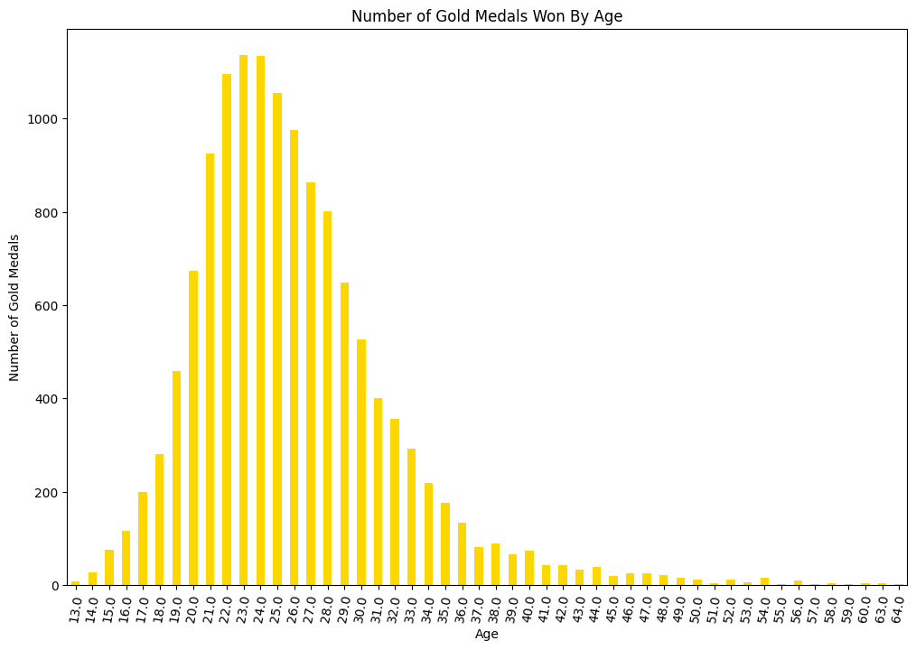

```python
# Plot the data as a bar graph with Age on the x-axis and number of gold medals on the y-axis
plt.figure(figsize=(12, 8))
gold_counts.plot(kind='bar',color ='gold')
plt.xlabel('Age')
plt.ylabel('Number of Gold Medals')
plt.title("Number of Gold Medals Won By Age")
plt.xticks(rotation = 80)
plt.show()
```

Based on this bar chart, we can see a very consistent data peak. The peak seems to be between 22 to 24. The ages that have won the most medals are 23 and 24. It is said that an athlete's physical prime is somewhere between 20 to 30 years old. Based on this data alone, it could be relevant to this statement. The amount of gold medals won diminishes as the age increases.

### **Question 9:** What are the number of Olympics that each athlete competed in?

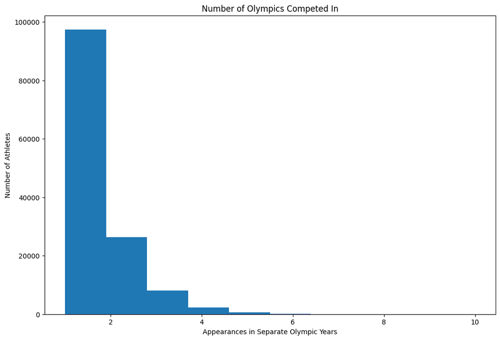

```python
# Converts years to year format
df['Year'] = pd.to_datetime(df['Year'], format='%Y').dt.year

# Groups athletes by year
athlete_years = df.groupby('Name')['Year'].nunique()

# Plot the data
plt.figure(figsize=(12, 8))
athlete_years.plot(kind="hist")
plt.title("Number of Olympics Competed In")
plt.xlabel("Appearances in Separate Olympic Years")
plt.ylabel("Number of Athletes")
```

### **Question 10:** Do medalists often get another medal? Which athletes have the most medals total?

```python
# Finds how many times an athlete’s name appears in the data frame
only_medalists = df[["Name", "Medal"]]
only_medalists = only_medalists.dropna(axis='index', subset=["Name", "Medal"])
athlete_counts = only_medalists["Name"].value_counts()
# Selects athletes who have won more than one medal
multiple_medalists = athlete_counts[athlete_counts > 1]
# Calculates the percentage of athletes who have won more than one medal
percentage_multiple_medalists = (len(multiple_medalists) / len(athlete_counts)) * 100
rounded_percentage = round(percentage_multiple_medalists, 2)
print(rounded_percentage)
# Finds the names of the athletes and their information
multiple_medalists_names = multiple_medalists.index.tolist()
print(multiple_medalists_names[:10])
```

[output not shown]

```python
multiple_medalists_info = df[df['Name'].isin(multiple_medalists_names)]
multiple_medalists_info.head(5)
```

[output not shown]

[figure not shown]

```python
# Finds the count for medals for individuals and sorts them from largest to smallest
medal_counts = multiple_medalists_info.groupby('Name')['Medal'].count()
medal_counts_sorted = medal_counts.sort_values(ascending=False)
# Makes the plot
plt.figure(figsize=(12, 8))
medal_counts_sorted.head(20)[::-1].plot(kind='barh', color='skyblue')
plt.title('Top 20 Athletes with Multiple Medals')
plt.xlabel('Number of Medals')
plt.ylabel('Athlete')
plt.tight_layout()
plt.show()
```

## **Conclusions**

These visualizations aid in contributing to the rise of data science in sports. Overall, they serve to filter a large dataset so that individuals have the opportunity to see different relationships between different countries, participants, medals won, and physical characteristics over time for the Olympics. Each of the ten visualizations aims to provide the viewer with a visually appealing representation of the data that shows a relationship between two or more variables in the data that allows for a deeper understanding of a specific amount and type of the Olympic data.